# NHL Data Analysis

## Data setup

Setup your working directory:

```r
setwd("C:/Users/farre/Desktop/nhl")
```

Import the data:

```r
data <- import("./data")
```

```
##
## Importing 2017...
##
## [1] "Importing: ./data/2017_ES.csv"
## [1] "Importing: ./data/2017_PK.csv"
## [1] "Importing: ./data/2017_PP.csv"
## [1] "Importing: ./data/2017_TOT.csv"
##
## Importing 2018...
##
## [1] "Importing: ./data/2018_ES.csv"
## [1] "Importing: ./data/2018_PK.csv"
## [1] "Importing: ./data/2018_PP.csv"
## [1] "Importing: ./data/2018_TOT.csv"
##
## Merging 2017 and 2018...
```

I’m not going very deep into what variables are polluted due to the amount of time this has taken and doing so would take, but there are some variables that are clearly polluted and their values should be checked. For example, `TOT_CHIP` has values that have monetary representations but also others that don’t, and which don’t seem to be in the same units of scale. See the following output to get a better idea. When doing the data cleaning, this are all transformed into numeric variables, but they are problematic and should be investigated further.

```r
unique(data[, "TOT_CHIP"])
```

```
##   [1] NA              "$932,926.83"   "$144,969.51"   "$33,089.41"
##   [5] "$107,469.51"   "$15,853.66"    "$998,780.49"   "$270,731.71"
##   [9] "$15,406.51"    "$114,938.96"   "$96,646.34"    "$585,365.85"
##  [13] "$293,292.68"   "$8,170.73"     "$1,510,975.61" "$536,585.37"
##  [17] "$43,617.90"    "$29,878.05"    "$21,341.46"    "$54,878.05"
##  [21] "$73,170.73"    "$21,808.95"    "$1,065,853.66" "$320,121.95"
##  [25] "$80,487.80"    "$106,097.56"   "$22,560.98"    "$251,524.39"
##  [29] "$104,898.43"   "0"             "$48,780.49"    "$239,024.39"
##  [33] "$47,987.78"    "$1,400,000.00" "$7,906.50"     "$1,630,661.98"
##  [37] "$23,170.73"    "$134,146.34"   "$384,146.34"   "$429,268.29"
##  [41] "$35,060.98"    "$126,829.27"   "$65,853.66"    "$1,170,731.71"
##  [45] "$146,341.46"   "$204,878.05"   "$711,382.17"   "$127,439.02"
##  [49] "$439,024.39"   "$143,292.68"   "$198,170.73"   "$349,695.12"
##  [53] "$163,567.13"   "$472,560.98"   "$185,365.85"   "$14,227.65"
##  [57] "$203,048.78"   "$7,317.07"     "$4,526,829.27" "$402,439.02"
```

[output cut: 122 more lines]

If you want to see proportions in a case-by-case (i.e. “by row” or “by column”), you can remove the `summary()` function that wrapping any of it.

```r
summary(proportion_of_nas_per_observation(data))
```

```
##    Min. 1st Qu.  Median    Mean 3rd Qu.    Max.
##  0.2683  0.3113  0.4611  0.5316  0.8127  0.8850
```

```r
summary(proportion_of_nas_per_variable(data))
```

```
##    Min. 1st Qu.  Median    Mean 3rd Qu.    Max.
##  0.0000  0.3345  0.6667  0.5316  0.6678  0.8948
```

To reduce the NA proportions in the data, we look for observations and variables that have proportions larger than `NA_OBS_PROPORTION_THRESHOLD` and `NA_VAR_PROPORTION_THRESHOLD`, respectively, and delete them if they do. In the case of variables, there’s a `NA_VAR_WHITELIST` variable that will keep any variables inside it, even if they don’t pass the NAs proportion test. All of these constants can be modified in the `constants.R` file.

Since I’m not familiar with the data, I can’t know which variables whould be white-listed, but, if you do, you should definitely add them to the appropriate parameter in the `cosntants.R` file.

```r
before_n_obs <- nrow(data)
before_n_vars <- ncol(data)
```

```r
data <- clean(data)
```

```
##
## Cleaning non-whitlisted character variables...
##
##
## Keeping variables with acceptable NA proportions...
##
##
## Keeping observations with acceptable NA proportions...
##
##
## Keeping observations non-NA salary...
##
##
## Disaggregating due to players with multiple teams...
##
```

[output cut: 38 more lines]

After we apply our cleaning process, the mean proportion of NAs for both variables and observations goes down to 0.38 and we keep 44% of the variables and 70% of the observations, which is not too bad at all given the huge proportion of NAs in the data. Note that this also acts as an initial variable selection procedure, and it can be relaxed or made more restrictive by modifying the `NA_OBS_PROPORTION_THRESHOLD` and `NA_VAR_PROPORTION_THRESHOLD` in the `constants.R` file.

```r
summary(proportion_of_nas_per_observation(data))
```

```
##    Min. 1st Qu.  Median    Mean 3rd Qu.    Max.
## 0.00000 0.02445 0.71394 0.37783 0.71394 0.72127
```

```r
summary(proportion_of_nas_per_variable(data))
```

```
##      Min.   1st Qu.    Median      Mean   3rd Qu.      Max.
## 0.0000000 0.0005283 0.5055468 0.3778288 0.5108294 0.8954041
```

```r
ncol(data) / before_n_vars
```

```
## [1] 0.4479737
```

```r
nrow(data) / before_n_obs
```

```
## [1] 0.7089888
```

This is the clean and pre-processed data set, and it’s saved for reference (before teh variable selection process is applied), since it may be easier to check for correctness outside of R.

```r
write.csv(data, "./data.csv", row.names = FALSE)
```

Now we are going to impute the mode to each NA in each categorical variable, and the mean in the case of numerical variables. If we don’t do this, the, sill very large, number of NAs will produce errors in our variable selection and model training processes. After the imputation, we separete the data into our train, test, and full data sets

```r
data <- separate(impute(data))
```

## Visualizations

Salary distribution:

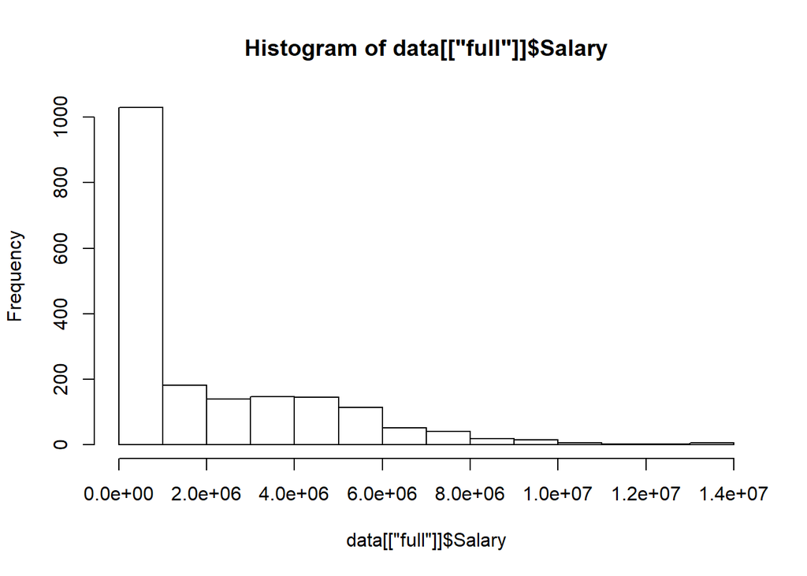

```r
hist(data[["full"]]$Salary)
```

Since there’s a very large number of numeric variables, we can’t generate a single correlations plots that has all the information simultaneously. We show the correlations by variable random samples, which means that you should execute the following code multiple times to get a rough estimate of the correlations among all variables.

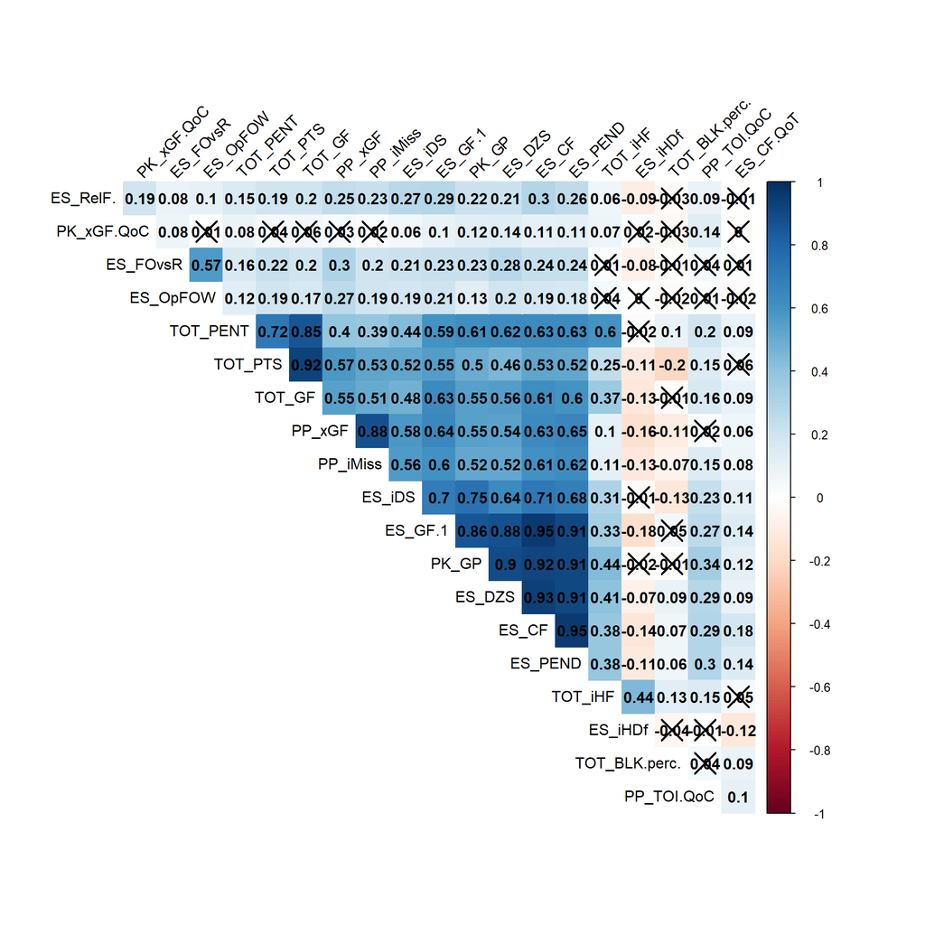

```r
random_correlations_graph(data, n_variables = 20)
```

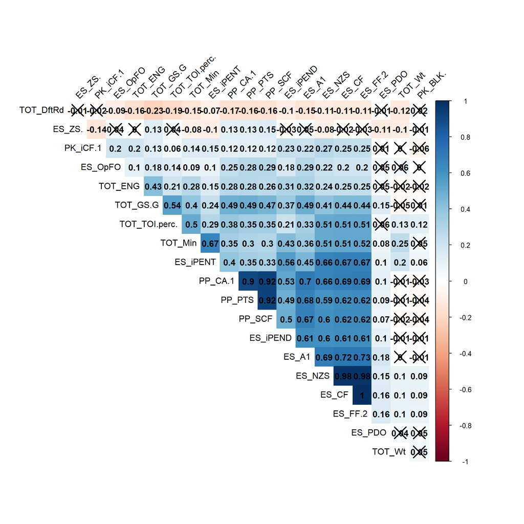

```r
random_correlations_graph(data, n_variables = 20)
```

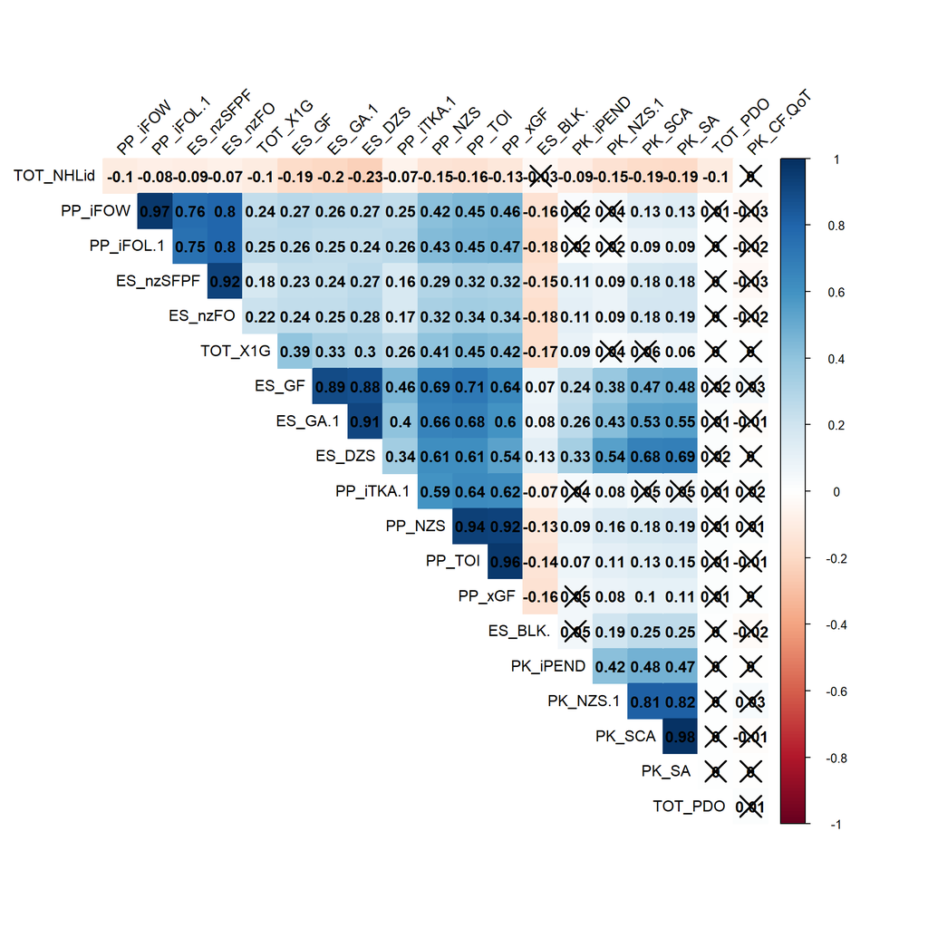

```r
random_correlations_graph(data, n_variables = 20)
```

The following code automatically generate multiple correlations graphs and saves them to disk for you. You can modify the parameters to your liking. Values marked with a cross on top of them mean that their p-value is larger than 0.01.

```r
generate_multiple_random_correlation_graphs(
    n_variables = 20,
    n_graphs = 10,
    data = data
)
```

We also are able to create scatter graphs where the size of each point is determined a variable’s value, and the color is determined by the salary. Some examples of the different patterns that can be found with these graphs are the following. Note that to interpret these correctly good domain knowledge about NHL and the measured variables is required, but even if no such knowledge is available, some interesting ideas can be infered for data cleaning and feature engineering purposes. Like these, tere are many other interesting patterns hidden in this data.

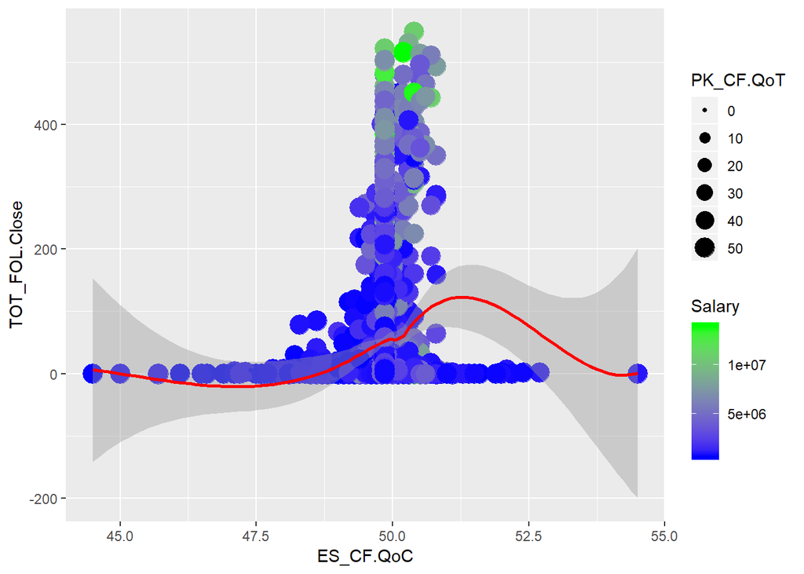

```r
scatter_graph_with_size_and_salary_color(
    data,
    x = "ES_CF.QoC",
    y = "TOT_FOL.Close",
    size = "PK_CF.QoT"
)
```

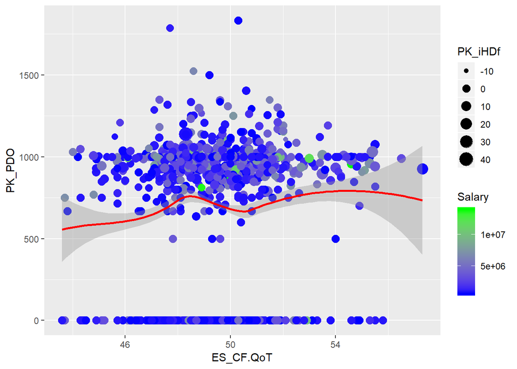

```r
scatter_graph_with_size_and_salary_color(
    data,
    x = "ES_CF.QoT",
    y = "PK_PDO",
    size = "PK_iHDf"
)
```

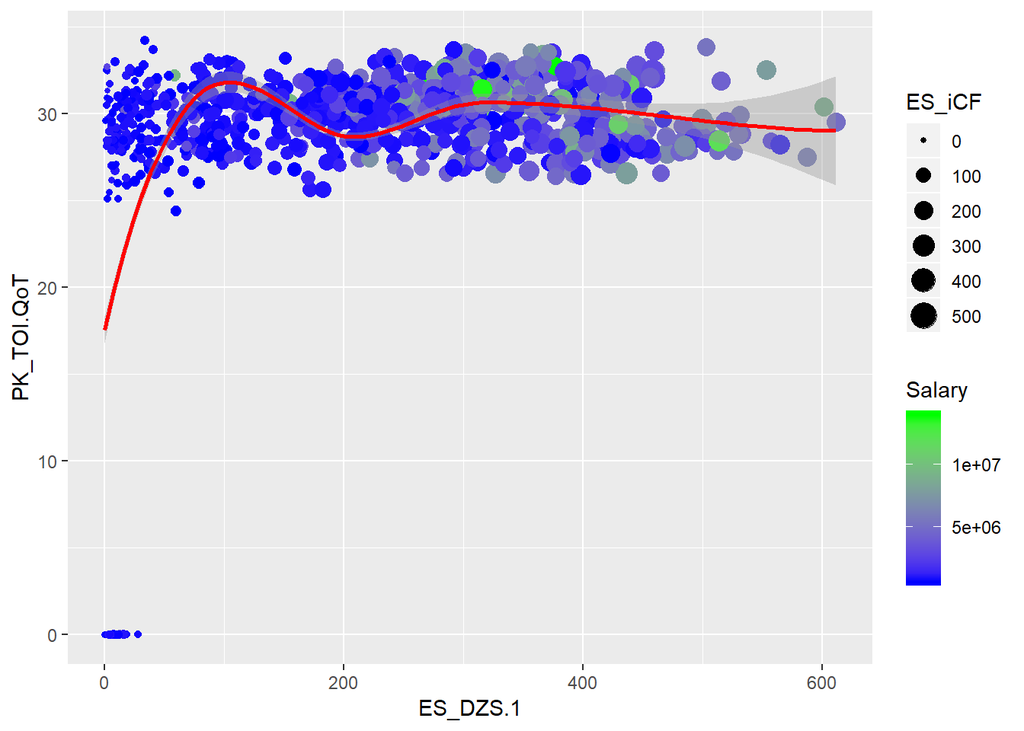

```r
scatter_graph_with_size_and_salary_color(
    data,
    x = "ES_DZS.1",
    y = "PK_TOI.QoT",
    size = "ES_iCF"
)
```

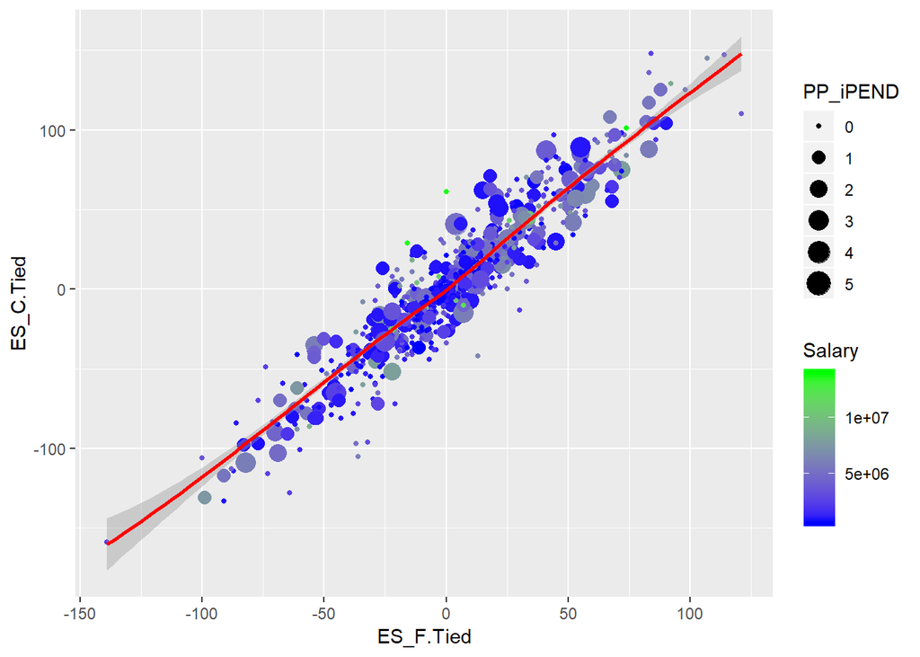

```r
scatter_graph_with_size_and_salary_color(
    data,
    x = "ES_F.Tied",
    y = "ES_C.Tied",
    size = "PP_iPEND"
)
```

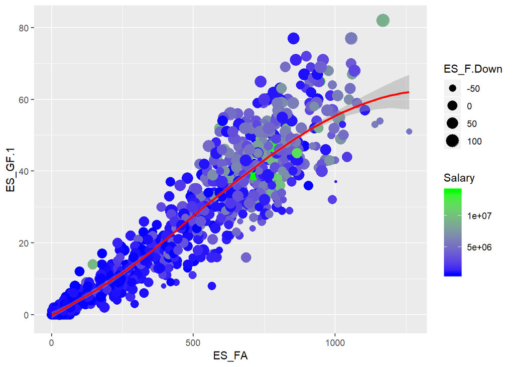

```r
scatter_graph_with_size_and_salary_color(
    data,
    x = "ES_FA",
    y = "ES_GF.1",
    size = "ES_F.Down"
)
```

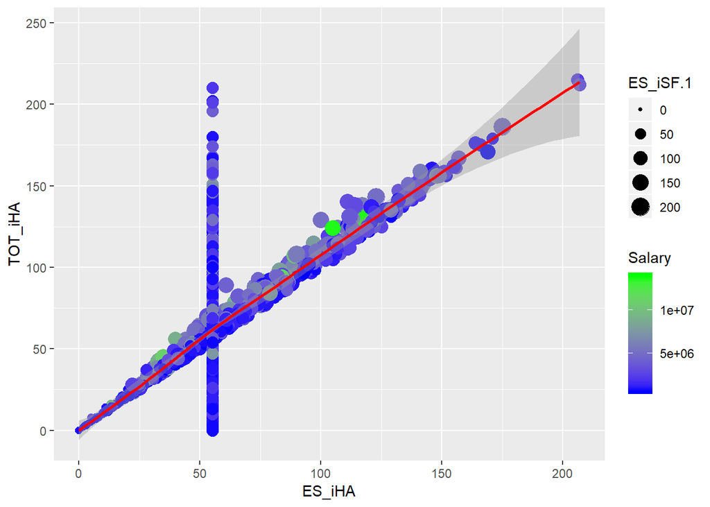

```r
scatter_graph_with_size_and_salary_color(
    data,
    x = "ES_iHA",
    y = "TOT_iHA",
    size = "ES_iSF.1"
)
```

To create `n_graphs` random graphs (the combinations for all available graphs are too much to create at once, it would be around 10,827,401) we use the following:

> **CAUTION**: The following code can take a long time to finish depending on how many graphs you specify. To avoid any problems, it’s not activiated here and is just left as reference.

```r
generate_multiple_random_scatter_graphs(
    n_graphs = 100,
    data = data
)
```

The scatter graphs created show some very interesting behavior for many combinations. Those visualizations together with domain knowledge around the problem can help with cleaning and feature engineering to increase the predictive power of the models, and it’s something that I recommend you explor further.

## Variable selection

Variable selection is performed with two steps. First, we remove variables which are highly correlated with others. The logic behind this is that if they are highly correlated the information they provide for the analysis is redundant, and, given the large number of variables in the analysis, we want to minimize the number of them while we maximize the information kept. The second step is performed with Recursive Feature Elimination (RFE).

The `selection` object contains the following attributes: `data` which is the data with the variable selection applied, `graph` which shows the accuracy change as more variables are added, `n_variables` which is the number of variables selected, and `variables` which are the variables actually selected. Internally, Random Forests are used to measure variable importance.

```r
selection <- variable_selection(data, "Salary")
```

```
##
## Removing variables with high correlations...
##
##
## Variables removed (288):
##
##
##   [1] "ES_CA"         "ES_CA.1"       "ES_CA.2"       "ES_CA.3"
##   [5] "ES_CF"         "ES_CF.1"       "ES_CF.2"       "ES_CF.3"
##   [9] "ES_DZS"        "ES_DZS.1"      "ES_DZS.2"      "ES_dzSAPF"
##  [13] "ES_dzSFPF"     "ES_Exp.dzNGPF" "ES_Exp.dzNSPF" "ES_Exp.ozNGPF"
##  [17] "ES_Exp.ozNSPF" "ES_F.Close"    "ES_FA"         "ES_FA.1"
##  [21] "ES_FA.2"       "ES_FA.3"       "ES_FF"         "ES_FF.1"
##  [25] "ES_FF.2"       "ES_FF.3"       "ES_FOvsL"      "ES_FOvsR"
##  [29] "ES_GA.1"       "ES_GF"         "ES_GF.1"       "ES_GP"
##  [33] "ES_iCF"        "ES_iCF.1"      "ES_iDS"        "ES_iFF"
##  [37] "ES_iFF.1"      "ES_iFOL"       "ES_iFOL.1"     "ES_iFOW"
##  [41] "ES_iFOW.1"     "ES_iGVA"       "ES_iSF"        "ES_iSF.1"
##  [45] "ES_iTKA"       "ES_ixG"        "ES_nzFO"       "ES_NZS"
##  [49] "ES_NZS.1"      "ES_nzSAPF"     "ES_nzSFPF"     "ES_OpFO"
##  [53] "ES_OpFOW"      "ES_ozFO"       "ES_OZS"        "ES_OZS.1"
##  [57] "ES_OZS.2"      "ES_ozSAPF"     "ES_ozSFPF"     "ES_Pass"
##  [61] "ES_PEND"       "ES_PENT"       "ES_PTS"        "ES_PTS.60"
##  [65] "ES_RelF."      "ES_RopFO"      "ES_SA"         "ES_SA.1"
##  [69] "ES_SCA"        "ES_SCF"        "ES_SF"         "ES_SF.1"
##  [73] "ES_SH."        "ES_TOI"        "ES_TOI."       "ES_TOI.1"
##  [77] "ES_TOI.2"      "ES_TOI.3"      "ES_TOI.GP"     "ES_TOI.QoT"
##  [81] "ES_xGA"        "ES_xGF"        "PK_CA.1"       "PK_CF"
##  [85] "PK_CF.1"       "PK_DZS"        "PK_FA"         "PK_FA.1"
##  [89] "PK_FF"         "PK_FF.1"       "PK_GA"         "PK_GA.1"
##  [93] "PK_GF.1"       "PK_GP"         "PK_iBLK"       "PK_iFF"
##  [97] "PK_iFOW"       "PK_iGVA"       "PK_iHF"        "PK_iHF.1"
## [101] "PK_iMiss"      "PK_iSF"        "PK_iSF.1"      "PK_iSF.2"
## [105] "PK_iTKA"       "PK_iTKA.1"     "PK_ixG"        "PK_NZS"
## [109] "PK_NZS.1"      "PK_OZS"        "PK_Pass"       "PK_PDO"
## [113] "PK_PEND"       "PK_PTS"        "PK_SA"         "PK_SA.1"
## [117] "PK_SCA"        "PK_SCF"        "PK_SF"         "PK_SF.1"
## [121] "PK_SV."        "PK_TOI"        "PK_TOI."       "PK_TOI.1"
## [125] "PK_TOI.2"      "PK_TOI.GP"     "PK_TOI.QoT"    "PK_xGA"
## [129] "PK_xGF"        "PK_xGF.QoT"    "PK_ZS."        "PP_CA"
```

[output cut: 110 more lines]

```
## Outer resampling method: Cross-Validated (2 fold)
##
## Resampling performance over subset size:
##
##  Variables    RMSE Rsquared    MAE RMSESD RsquaredSD MAESD Selected
##          5 1399898   0.6557 924782  51727   0.005570  1038
##         25 1306489   0.7030 850766  18393   0.005571 37674        *
##         45 1315033   0.7003 854590  22135   0.005771 35494
##         65 1362924   0.6877 895790  73953   0.004450 23042
##         85 1358628   0.6886 896070  70863   0.005494 16738
##        105 1357888   0.6890 894136  71030   0.005806 14764
##        115 1355922   0.6895 891246  73356   0.006198 16993
##
## The top 5 variables (out of 25):
##    TOT_Status, TOT_GS.G, TOT_DftYr, TOT_SCA, TOT_iBLK
```

To explore the selection results, you can use the following to see the filtered datasets, variables, and optimization graph.

```r
head(selection[["data"]][["full"]])
head(selection[["data"]][["train"]])
head(selection[["data"]][["test"]])
```

```r
selection[["n_variables"]]
```

```
## [1] 25
```

```r
selection[["variables"]]
```

```
##  [1] "TOT_Status"    "TOT_GS.G"      "TOT_DftYr"     "TOT_SCA"
##  [5] "TOT_iBLK"      "TOT_Over"      "TOT_DftRd"     "ES_TOI.QoC"
##  [9] "TOT_iPEND"     "TOT_GWG"       "TOT_iHF"       "TOT_SH.perc."
## [13] "TOT_Cntry"     "PP_A1"         "TOT_Pace"      "PP_PEND"
## [17] "TOT_Post"      "PP_Pace"       "TOT_EPM"       "TOT_PM"
## [21] "TOT_IPP.perc." "TOT_G.Snap"    "PP_GA"         "TOT_iHDf"
## [25] "TOT_X1G"
```

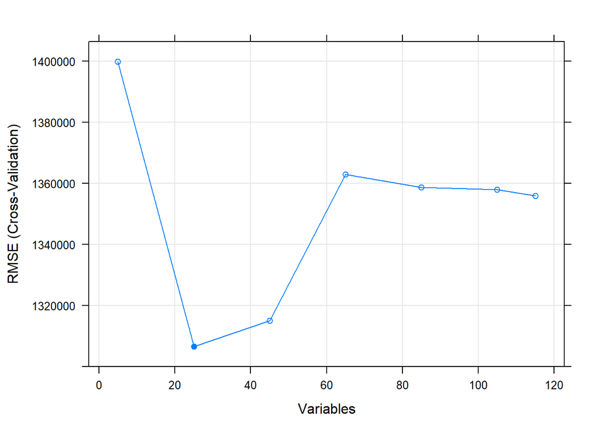

```r
selection[["graph"]]
```

## Model application

Feel free to add other models, you can find the full list here: https://topepo.github.io/caret/available-models.html

These models depend on external packages. If you don’t have installed in your system, when you execute the code, you’ll be notified that you don’t have them, and you’ll be asked whether you want to install them. If you do, execution will continue normally after the corresponding installations.

```r
models <- list(
    "random_forest" = "rf",
    "linear_regression" = "glm",
    "k_nearest_neighbors" = "knn"
)
```

```r
results <- best_results(selection[["data"]], "Salary", models)
```

```
## [1] "    - random_forest"
## [1] "    - linear_regression"
```

```
## [1] "    - k_nearest_neighbors"
```

## Results exploration

The `metrics` attribute has find three different accuracy metrics: `RMSE` (Root Mean Squared Error), `MAPE` (Mean Absolute Percentage Error), and `PPE10` (Percentage Predicted Error within 10%).

Models available:

```r
names(results)
```

```
## [1] "random_forest"       "linear_regression"   "k_nearest_neighbors"
```

Random Forest results:

```r
names(results[["random_forest"]])
```

```
## [1] "metrics"    "predictor"  "importance"
```

See the `predictor` object for Random Forests:

```r
results[["random_forest"]][["predictor"]]
```

```
## Random Forest
##
## 1325 samples
##   25 predictor
##
## No pre-processing
## Resampling: Cross-Validated (2 fold)
## Summary of sample sizes: 663, 662
## Resampling results across tuning parameters:
##
##   mtry  RMSE     Rsquared   MAE
##    2    1616292  0.5886752  1122702.3
##   23    1343105  0.6748149   842603.0
##   45    1349923  0.6693182   841237.8
##
## RMSE was used to select the optimal model using the smallest value.
## The final value used for the model was mtry = 23.
```

The results I’m seeing in average are the following. Note that these may be different every time you run the analysis because we’re not controlling the “seed” for the randomized algorithmns (this is done on purpose to see variuos results, but for publishing or sharing results with someone else, we should control the seed).

| Model | Metric | Value |
| --- | --- | --- |
| k-Nearest Neighbors | MAPE | 0.78 |
| k-Nearest Neighbors | RMSE | 1,254,133 |
| k-Nearest Neighbors | PPE10 | 0.11 |
| Linear Regression | MAPE | 0.94 |
| Linear Regression | RMSE | 1,149,743 |
| Linear Regression | PPE10 | 0.11 |
| Random Forest | MAPE | 0.50 |
| Random Forest | RMSE | 781,116 |
| Random Forest | PPE10 | 0.20 |

The results without the `Team` variable are (may be different for you):

| Model | Metric | Value |
| --- | --- | --- |
| k-Nearest Neighbors | MAPE | 0.78 |
| k-Nearest Neighbors | RMSE | 1,253,906 |
| k-Nearest Neighbors | PPE10 | 0.12 |
| Linear Regression | MAPE | 0.86 |
| Linear Regression | RMSE | 1,132,435 |
| Linear Regression | PPE10 | 0.10 |
| Random Forest | MAPE | 0.45 |
| Random Forest | RMSE | 769,135 |
| Random Forest | PPE10 | 0.24 |

```r
results[["k_nearest_neighbors"]][["metrics"]]
```

```
## $RMSE
## [1] 1284583
##
## $MAPE
## [1] 0.7544434
##
## $PPE10
## [1] 0.1232394
```

```r
results[["linear_regression"]][["metrics"]]
```

```
## $RMSE
## [1] 1147471
##
## $MAPE
## [1] 0.8187676
##
## $PPE10
## [1] 0.1109155
```

```r
results[["random_forest"]][["metrics"]]
```

```
## $RMSE
## [1] 800012.7
##
## $MAPE
## [1] 0.4372943
##
## $PPE10
## [1] 0.221831
```

See the “variable” `importance`, for a Random Forests

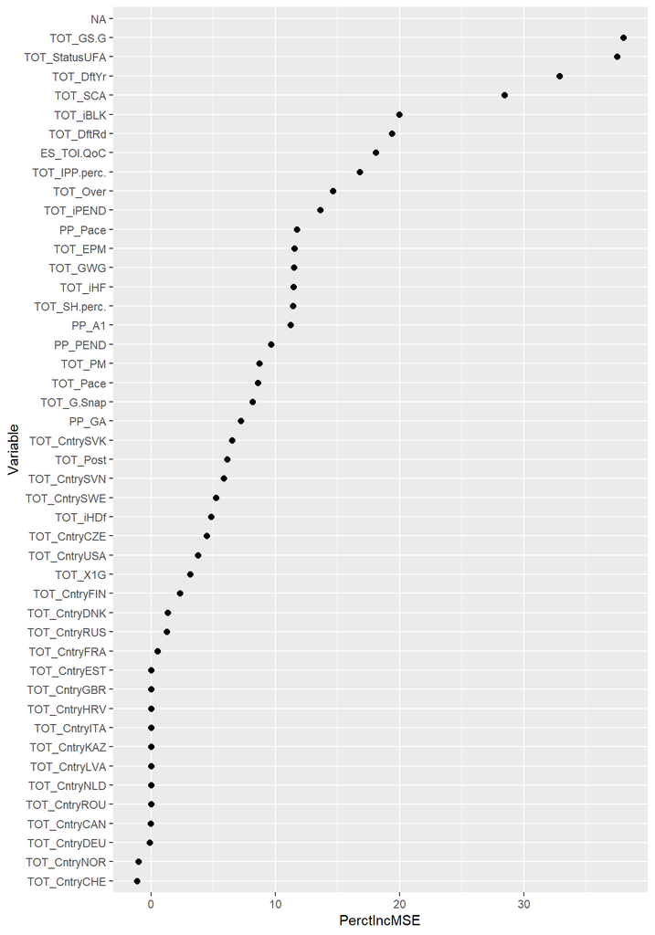

```r
results[["random_forest"]][["importance"]]
```

For “variable importance” for linear regression, you can look directly at the coefficients, standard errors, and p-values from the fitte model

```r
summary(results[["linear_regression"]][["predictor"]]$finalModel)
```

```
##
## Call:
## NULL
##
## Deviance Residuals:
##      Min        1Q    Median        3Q       Max
## -4796360   -881575     -1989    719147   8406536
##
## Coefficients:
##                 Estimate Std. Error t value Pr(>|t|)
## (Intercept)    2.873e+08  2.870e+07  10.009  < 2e-16 ***
## TOT_StatusUFA  1.001e+06  1.184e+05   8.452  < 2e-16 ***
## TOT_GS.G       2.165e+06  2.827e+05   7.658 3.71e-14 ***
## TOT_DftYr     -1.471e+05  1.421e+04 -10.352  < 2e-16 ***
## TOT_SCA        9.474e+02  2.733e+02   3.467 0.000544 ***
## TOT_iBLK       6.014e+03  1.716e+03   3.504 0.000473 ***
## TOT_Over       4.568e+04  1.713e+04   2.667 0.007759 **
## TOT_DftRd     -1.454e+05  2.375e+04  -6.122 1.23e-09 ***
## ES_TOI.QoC     3.074e+05  1.090e+05   2.821 0.004861 **
## TOT_iPEND      1.408e+04  9.400e+03   1.498 0.134267
## TOT_GWG        7.769e+04  3.741e+04   2.077 0.038011 *
## TOT_iHF       -6.747e+03  1.807e+03  -3.734 0.000197 ***
## TOT_SH.perc.   2.119e+03  1.296e+04   0.163 0.870218
## TOT_CntryCAN   1.136e+06  4.581e+05   2.481 0.013234 *
## TOT_CntryCHE   9.069e+05  5.727e+05   1.583 0.113567
## TOT_CntryCZE   1.428e+06  5.131e+05   2.782 0.005475 **
## TOT_CntryDEU   1.283e+06  6.433e+05   1.994 0.046395 *
## TOT_CntryDNK   1.076e+06  6.168e+05   1.745 0.081223 .
## TOT_CntryEST   1.217e+06  1.165e+06   1.045 0.296371
## TOT_CntryFIN   9.858e+05  5.025e+05   1.962 0.050020 .
## TOT_CntryFRA   4.882e+05  8.095e+05   0.603 0.546569
## TOT_CntryGBR   1.438e+06  1.148e+06   1.252 0.210659
## TOT_CntryHRV  -5.255e+05  1.575e+06  -0.334 0.738750
## TOT_CntryITA   2.669e+06  1.555e+06   1.716 0.086342 .
## TOT_CntryKAZ   6.369e+05  1.554e+06   0.410 0.682049
## TOT_CntryLVA   1.564e+06  1.561e+06   1.002 0.316735
## TOT_CntryNLD   1.492e+05  1.563e+06   0.095 0.923962
## TOT_CntryNOR   1.008e+06  8.074e+05   1.248 0.212219
## TOT_CntryROU   1.574e+06  1.557e+06   1.011 0.312323
## TOT_CntryRUS   1.774e+06  4.988e+05   3.556 0.000390 ***
```

[output cut: 11 more lines]

```
## TOT_IPP.perc. -1.105e+04  2.136e+03  -5.173 2.68e-07 ***
## TOT_G.Snap     1.126e+04  3.427e+04   0.328 0.742622
## PP_GA          3.340e+04  6.153e+04   0.543 0.587314
## TOT_iHDf       6.078e+03  1.846e+03   3.292 0.001020 **
## TOT_X1G        7.855e+04  3.386e+04   2.320 0.020513 *
## ---
## Signif. codes:  0 '***' 0.001 '**' 0.01 '*' 0.05 '.' 0.1 ' ' 1
##
## (Dispersion parameter for gaussian family taken to be 2.199484e+12)
##
##     Null deviance: 7.2346e+15  on 1324  degrees of freedom
## Residual deviance: 2.8131e+15  on 1279  degrees of freedom
## AIC: 41463
##
## Number of Fisher Scoring iterations: 2
```

## Predictions for specific player’s salary

Data we will use for predictions:

```r
select <- which(
    colnames(data[["full"]]) %in%
    c(colnames(selection[["data"]][["full"]]), ID_VARS)
)
d <- data[["full"]][, select]
```

Connor McDavid observations (note that there are two observations for him):

```r
connor_mcdavid <- d[
    d$Last.Name == "McDavid" &
    d$First.Name == "Connor" &
    d$Position == "C" &
    d$Team == "EDM",
]
```

Nine random players plus the two observatinos for Connor McDavid:

```r
players <- d[sample(1:nrow(d), 9), ]
players <- rbind(connor_mcdavid, players)
```

Get the actual predictions:

```r
avoid <- -which(colnames(players) %in% c(
    "Year",
    "Last.Name",
    "First.Name",
    "Position"
))
predictions <- predict(
    results[["random_forest"]][["predictor"]],
    players[, avoid]
)
```

Results for predictions, including Root-Square Error (RSE), Absolute Error (AE), and Absolute Percentage Error (APE).

```r
results <- data.frame(
    "First.Name" = players$First.Name,
    "Last.Name" = players$Last.Name,
    "Position" = players$Position,
    "Team" = players$Team,
    "Real" = players$Salary,
    "Predicted" = predictions
)
results$RSE <- sqrt((results$Real - results$Predicted)^2)
results$AE <- abs(results$Real - results$Predicted)
results$APE <- results$AE / results$Real

results
```

```
##       First.Name Last.Name Position Team    Real Predicted        RSE
## 510       Connor   McDavid        C  EDM  925000 1775711.5  850711.50
## 2003      Connor   McDavid        C  EDM  925000 2773208.3 1848208.33
## 2232        Jeff     Petry        D  MTL 6000000 5939776.3   60223.67
## 14971     Samuel    Girard        D  COL  742500  863389.6  120889.58
## 686        Kevin    Rooney        C  N.J  625000  670630.8   45630.80
## 34        Mathew    Barzal        C  NYI  925000  908539.8   16460.20
## 483      Brandon   Manning        D  PHI  950000 1392515.7  442515.71
## 2151      Markus Nutivaara        D  CBJ  842500 2229214.3 1386714.30
## 1646       Calle  Jarnkrok        C  NSH 1800000 2225297.8  425297.83
## 15831       Nick    Holden        D  BOS 1800000 2167227.0  367227.00
## 702         Luca     Sbisa        D  VAN 3600000 3435328.8  164671.23
##               AE        APE
## 510    850711.50 0.91968811
## 2003  1848208.33 1.99806306
## 2232    60223.67 0.01003728
## 14971  120889.58 0.16281426
## 686     45630.80 0.07300927
## 34      16460.20 0.01779481
## 483    442515.71 0.46580601
## 2151  1386714.30 1.64595169
## 1646   425297.83 0.23627657
## 15831  367227.00 0.20401500
## 702    164671.23 0.04574201
```